Home > Archives > Ggplot自构建函数需要注意的三个问题

# Ggplot自构建函数需要注意的三个问题

Publish: March 4, 2015

## 自构建ggplot函数需要注意的问题

1. 由于是在函数的环境创建图形，因此以数据框的格式向ggplot()传递参数时要格外小心。同时，要确保没有图形属性映射中误用了函数的任何局部变量。
2. 如果允许用户向图形属性映射中提供自定义变量，建议使用aes_string()。它与aes()相似，但是它使用字符串而不是未估值的表达式；比如aes(x=cyl)与aes_string(x=‘cyl’)是一样的，但是字符串比表达式更容易使用。
3. 数据变换和处理与绘图函数要切分为两个函数。

数据：

```r
head(mtcars)
```

```
##                    mpg cyl disp  hp drat    wt  qsec vs am gear carb
## Mazda RX4         21.0   6  160 110 3.90 2.620 16.46  0  1    4    4
## Mazda RX4 Wag     21.0   6  160 110 3.90 2.875 17.02  0  1    4    4
## Datsun 710        22.8   4  108  93 3.85 2.320 18.61  1  1    4    1
## Hornet 4 Drive    21.4   6  258 110 3.08 3.215 19.44  1  0    3    1
## Hornet Sportabout 18.7   8  360 175 3.15 3.440 17.02  0  0    3    2
## Valiant           18.1   6  225 105 2.76 3.460 20.22  1  0    3    1
```

比如现在我要写一个函数，这个函数调用ggplot进行画直方图,函数有两个参数，一个是数据框，一个是要画的这个列名

```r
library(ggplot2)
histogram<-function(df,lie){
ggplot(df)+geom_histogram(aes(x=cyl),fill="#880011")

#这时histogram(data=mtcars)可以画图，但是怎么把列名传递给函数内部的geom_histogram(aes(x=cyl))呢？

histogram(data=mtcars)
}
```

如果函数改为 ggplot(df)+geom_histogram(aes(x=lie),fill=”#880011″),如何传递列名？

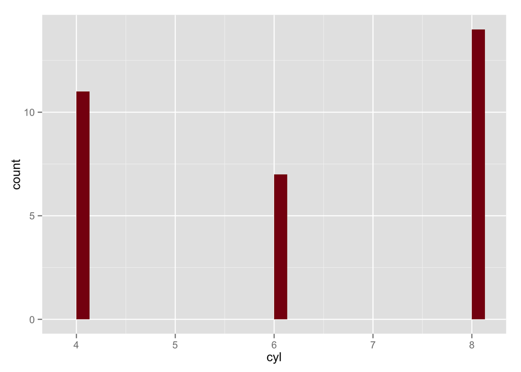

```r
#histogram(data=mtcars,lie=’cyl’),这种情况传递了‘cyl’这个字符，传递不了cyl列。
#histogram(data=mtcars,lie=cyl),这种情况会报错：错误于eval(expr, envir, enclos) : 找不到对象’lie’
#改用aes_string()可以解决这个问题。

histogram<-function(data,lie1){
  ggplot(data)+geom_histogram(aes_string(x=lie1),fill="#880011")
}

histogram(data=mtcars,lie='cyl')
```

声明: 本文采用 [BY-NC-SA](http://creativecommons.org/licenses/by-nc-sa/3.0/) 授权。转载请注明转自: tegulia

« Ggplot2直方图

分类算法的可视化探索 »